# Interrupted Time Series Analysis

## Assuming ‘day_level_aggregated’ contains columns ‘date’ and ‘fear_nrc’

We’ll need to create two columns, fear_nrc_before and fear_nrc_after, which will represent the fear_nrc values before and after the intervention, respectively.

Here’s how to adjust the dataset and create a ggplot:

Create a variable to represent the number of days relative to the intervention date (date_diff). Split the data into two parts: one for the period before the intervention (d_before) and one for the period after the intervention (d_after). Merge these datasets back together so that you have a continuous dataset with the intervention point as a reference.

```r
library(dplyr)
intervention_date <- as.Date("2020-12-14")
day_level$date <- as.Date(day_level$date)

# Calculate the number of days relative to the intervention date
day_level$date_diff <- day_level$date - intervention_date

# Data before the intervention
d_before <- day_level %>% filter(date_diff < 0)

# Data after the intervention
d_after <- day_level %>% filter(date_diff >= 0)

# Assuming you want to merge on the interval (number of days relative to the intervention)
d_merge <- merge(d_before, d_after, by = "date_diff", all = TRUE)

#create two columns for the line before and afer the intervention

d_merge <- day_level %>%
  mutate(fear_nrc_before = ifelse(date_diff < 0, fear_nrc, NA),
         fear_nrc_after = ifelse(date_diff >= 0, fear_nrc, NA))

d_merge$date_diff<-as.numeric(d_merge$date_diff)
#hist(d_merge$date_diff)
```

Now plot it

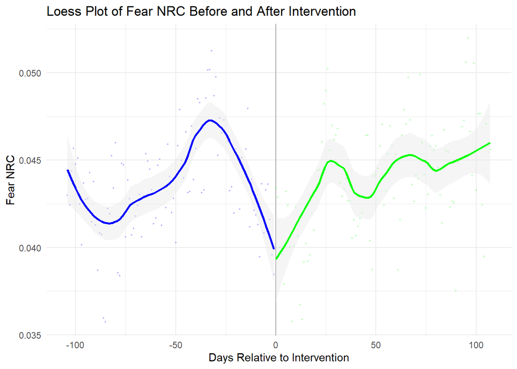

```r
library(ggplot2)

ggplot() +
  geom_vline(xintercept = 0, linetype="solid", col="black", alpha=0.3, size=0.5) +

  geom_point(data = d_merge, aes(x = date_diff, y = fear_nrc_before), color = "blue", alpha = 0.3, shape = 16, size = 0.3) +
  geom_smooth(data = d_merge, aes(x = date_diff, y = fear_nrc_before), method = "loess", color = "blue", se = TRUE, size = 1, span = 0.5, fill = "grey90") +

  geom_point(data = d_merge, aes(x = date_diff, y = fear_nrc_after), color = "green", alpha = 0.3, shape = 16, size = 0.3) +
  geom_smooth(data = d_merge, aes(x = date_diff, y = fear_nrc_after), method = "loess", color = "green", se = TRUE, size = 1, span = 0.5, fill = "grey90") +

  theme_minimal() +
  labs(
    title = "Loess Plot of Fear NRC Before and After Intervention",
    x = "Days Relative to Intervention",
    y = "Fear NRC"
  )
```

## Extra: Normalizing the Data

Here’s how you can normalize each emotion-related variable in your combined_emotion dataframe to have a mean of 0 and a standard deviation of 1:

```r
# Normalize the data (standardization)
combined_emotion_normalized <- combined_emotion
combined_emotion_normalized[emotion_cols] <- scale(combined_emotion[emotion_cols])

# Check the structure of the normalized data
# str(combined_emotion_normalized)
```

# Creating Histograms of Normalized Data

After normalizing, you can create histograms to visualize the distribution of each normalized variable:

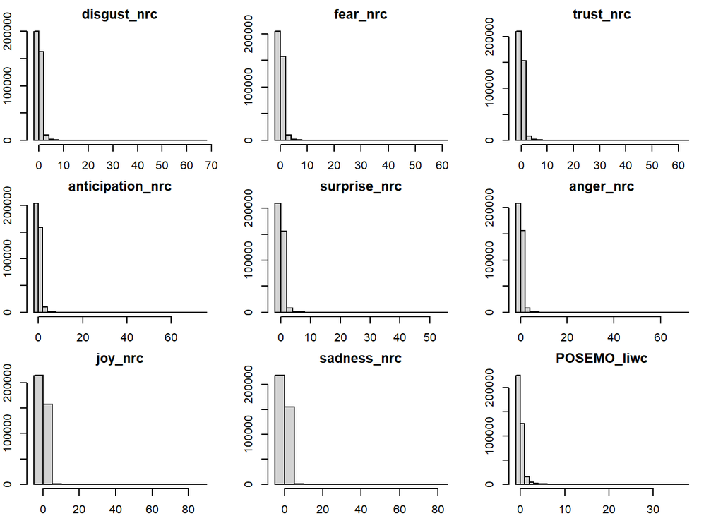

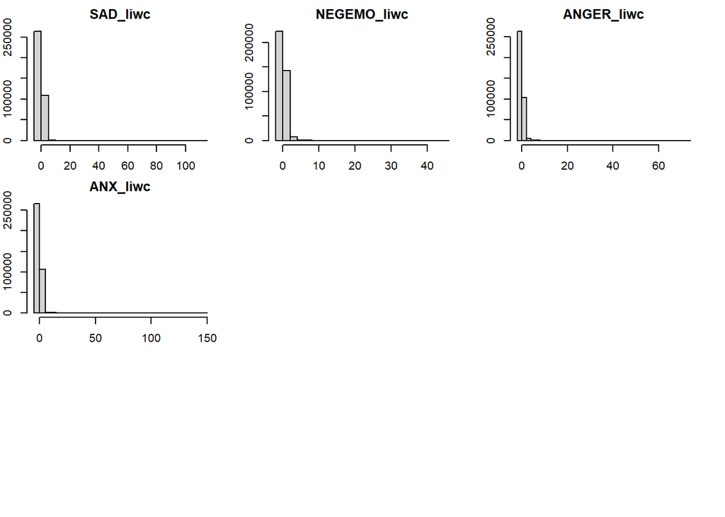

```r
# Set smaller margins

par(mar=c(2, 2, 2, 2))

par(mfrow = c(3, 3)) # Adjust based on your needs

# Create histograms for each emotion-related variable

for (col in emotion_cols) {
  hist(combined_emotion_normalized[[col]], main = col, xlab = col, breaks = 30) }# 'breaks' controls the number of bins
```